# Experimental Research

PSCI 2270 - Week 10

Alec Tripp and Georgiy Syunyaev

Department of Political Science, Vanderbilt University

October 31, 2024

## Plan for this week

1. Censorship in China
2. Attitudes towards immigrants
3. Campaign contributions and access

## Summarizing experimental design

- What is the research hypothesis?
- What are the experimental conditions?
- Who (or what) are the subjects?
- How are the subjects assigned to treatment(s)?
- In what context does the experiment take place?
- How are outcomes measured?
- How do researchers estimate average treatment effect?
- Are there any threats to inference? Think about random assignment, non-interference, excludability, experimenter effects, treatment meaning

# Censorship in China

## Censorship in China

- *“Reverse-Engineering Censorship in China: Randomized Experimentation and Participant Observation.”* by King, Pan, and Roberts (2014)
- Summary:
  - Experimental study on what is being censored on the social media platforms in China
  - Two competing theories: Anti-government statements vs. collective action statements
  - Conduct participant observation to provide qualitative evidence on how the censorship is structured
  - Created and posted on the internet many posts varying whether it contains collective action topics and whether they have pro- or anti-government statements
  - Find strong evidence in favor of censorship of collective action statements

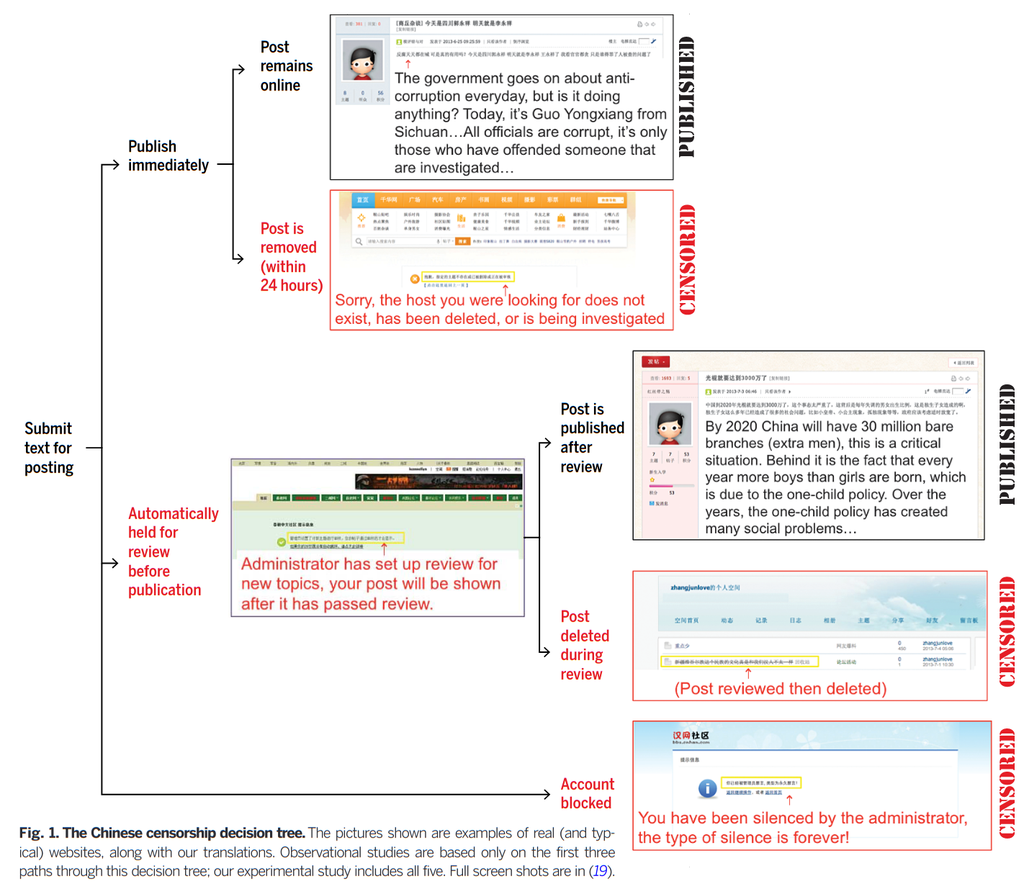

## What is the research hypothesis?

- Why do autocrats want to do censorship?
  - To stay in power and prevent public from overthrowing them
- How can this be achieved with censorship?
  1. By projecting positive image of the leader $\Rightarrow$ censor anti-government discussions
  2. By making people believe that no one is dissastisfied with the government $\Rightarrow$ censor collective action
- Hypothesis: Authors claim that the collective action theory is true but not the theory about positive image of the government.

## What is the key motivation?

- There was a study conducted before using the observed posts on Chinese social media
  - Findings were that collective action is censored but not the government criticism
- Why there could be issues with this study?
  - Possible confounders
  - Possible selection bias

## Experimental conditions? Subjects?

- What is the treatment in the study? **Two separate treatments**
  1. Social media posts with collective action vs those without collective action potential
  2. Social media posts that take pro-government vs anti-government stance
- Who (or what) are the subjects?
  - Not humans (!) but rather social media posts
- **Design:** Factorial audit experiment
  - Factorial design: We have two separate treatments and we create experimental groups that have all possible ($2^2$) combinations of them: $00$ (control), $01$, $10$, $11$
  - Audit experiment: Measure responsiveness and discrimination in bureacracy, government, other organizations. Treatments are some actions that should trigger a response (usually from government).

## Treatment assignment and context

- How did they assign the treatment?
  - Scraped the topics during the study and wrote the posts themselves
  - Randomly assigned posts during the study
- What is the context of the study?
  - Selected 100 Chinese social media platforms and created users on them
  - 12 posts per social media with 1200 total sample size
- Possible issues?
  - Excludability: How do they ensure posts do not differ on dimensions other than pro-/anti-government and collective/non-collective action information?
  - What is treatment: Are the topics they select actually representative of collective action posts?
  - Random assignment: Is the random procedure clear?

## Outcomes? Analysis?

- What are the outcomes they measure?
  1. Post selected for automated review
  2. Post censored (either after review or after publishing)

## Outcomes explained

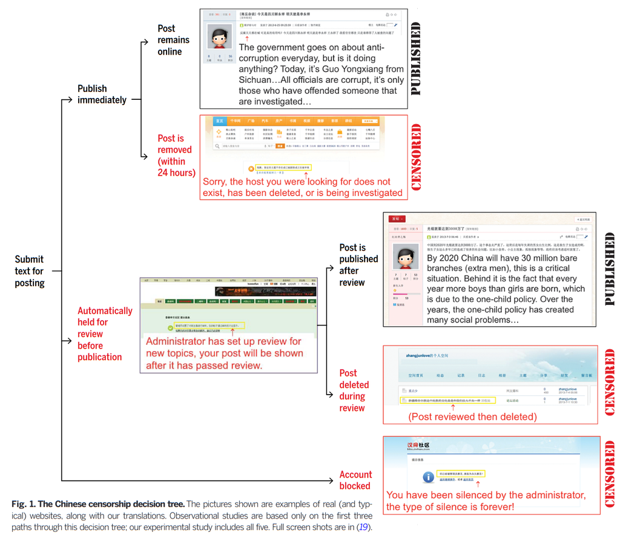

## Outcomes? Analysis?

- What are the outcomes they measure?
  1. Post selected for automated review
  2. Post censored (either after review or after publishing)
- How do they analyze the data?
  - Look at differences in means for each treatment (collective action or no/pro- or anti-government) separately
  - This is the *beauty* of factorial designs!

## Main results

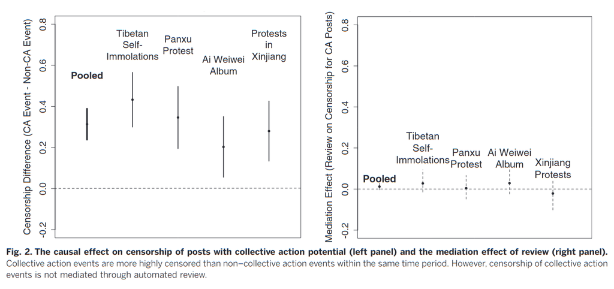

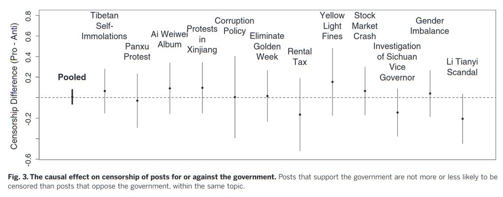

## Let’s discuss concerns

- Should we be concerned about non-interference? Likely No!
- Should we be concerned about experimenter effects? Yes!
- Should we be concerned about excludability? Likely No!
- Should we be concerned that topics were picked from the pool of observed posts? Not for experimental part!
- Any other concerns?
  - Should we be concerned about writers of the experimental posts?
- Do you think audit experiments are useful? Where else can we use them?

# Attitudes towards immigrants

## Attitudes towards immigrants

- *“The Hidden American Immigration Consensus: A Conjoint Analysis of Attitudes Toward Immigrants.”* by Hainmueller and Hopkins (2015)
- Summary:
  - Experimental study on preferences of Americans for types of immigrants
  - Theories: Partisan, economic and sociotropic factors could affect preferences for immigrants
  - Conduct a study where respondents are asked to compare two immigrant profiles at a time
  - Find support for overall preferences for high-skilled and educated immigrants who plan to work, but no differences across partisan attachment

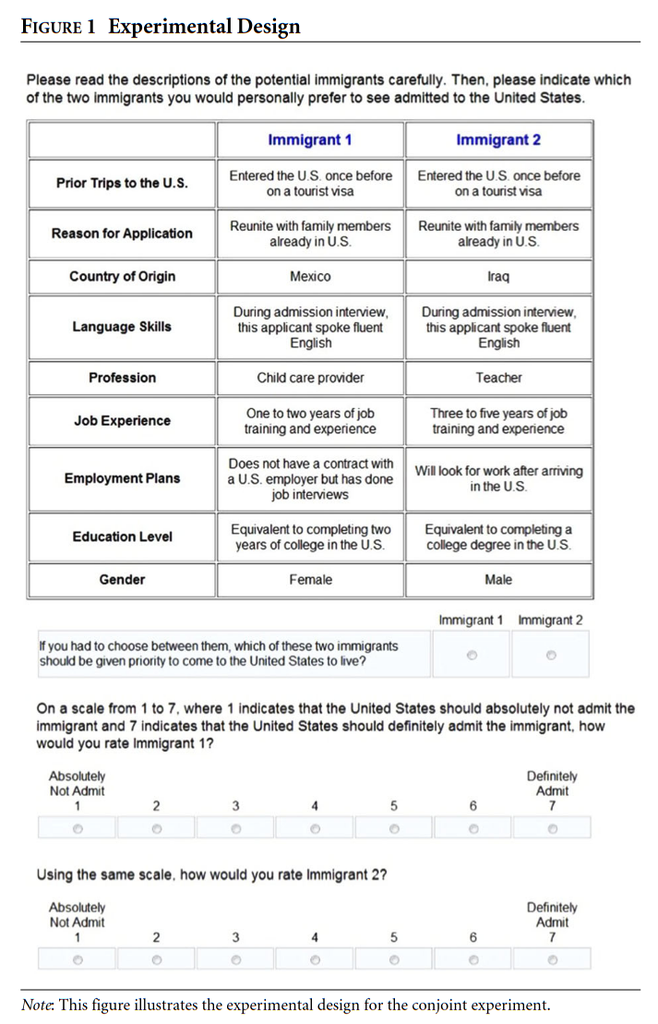

## What is the research hypothesis?

- There is a perception that Democrats and Republicans vary in terms of their preferences on immigration policy
  - Democrats are expected to be more accepting of immigrants regardless of their profiles
- Alternative theories
  - **Economic:** Job threat as a factor that affects prefferences on immigration
  - **Sociotropic:** Preferences for immigrants who are more likely to contribute to the economy
  - **Norms-based:** Preferences for immigrants who are more likely to assimilate
  - **Prejudice:** Preferences for white/European immigrants

## Experimental conditions? Subjects?

- What is the treatment in the study? **Many separate treatments**
  - Prior trips; Reasons for application; Country of origin; Language skills; Profession; Job experience; Employment plans; Education level; Gender… 🤯
- Who (or what) are the subjects?
  - Americans in nationally representative panel study
- **Design:** Conjoint experiment
  - $\approx$ factorial design on steroids!
  - Borrowed from marketing research where it is used to test different product features. Allows for testing of large list of features
  - Ask people to rate or compare different profiles (not necessary of humans, e.g. policies/laws/events)

## Treatment assignment and context

- How did they assign the treatment?
  - Showed two profiles with randomly assigned features (every feature is randomized separately)
  - There is 900,000 possible profiles, so not all profiles are used…
  - Is that a problem? No, because for each feature in expectation the profiles on other features are the same
- What is the context of the study?
  - Representative panel (i.e. interveiew each person more than once) survey in US
  - 1,714 completed first wave, 1,407 completed second wave
- Possible issues?
  - Random assignment: Is the random procedure clear?
  - Conceptual treatment: There is a priming component in listing a feature in the table. Are we sure those factors are all relevant?

## Outcomes? Analysis?

- What are the outcomes they measure?
  1. Comparison between two profiles
  2. Rating of profiles on absolute scale
- How do they analyze the data?
  - Look at differences in means for each feature (marginalized over other dimensions)
  - This is the *beauty* of factorial/conjoint designs!

## Outcomes explained

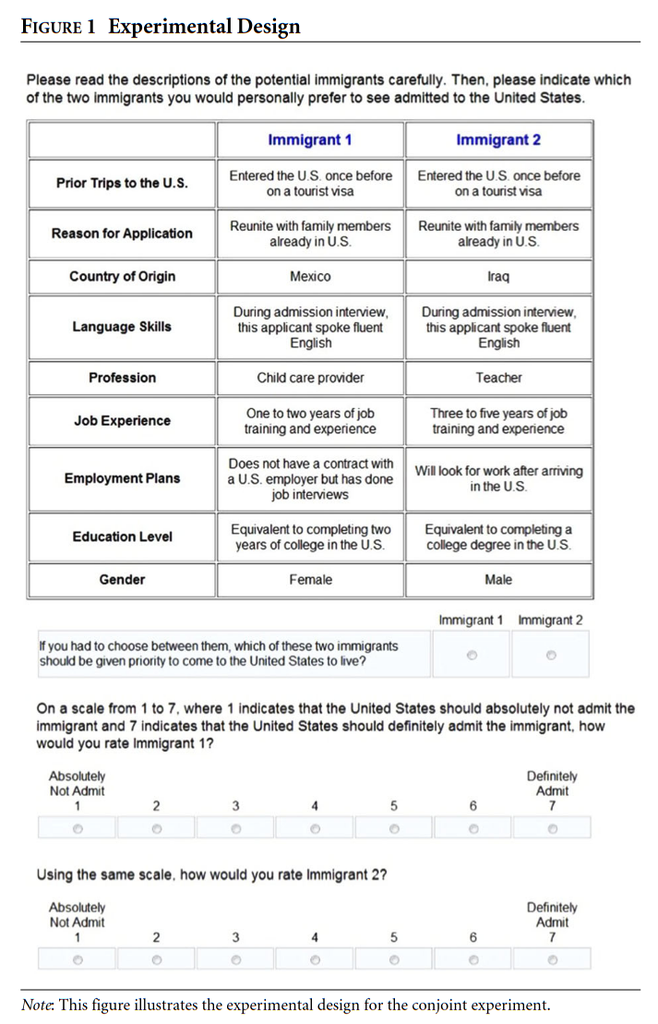

## Main results

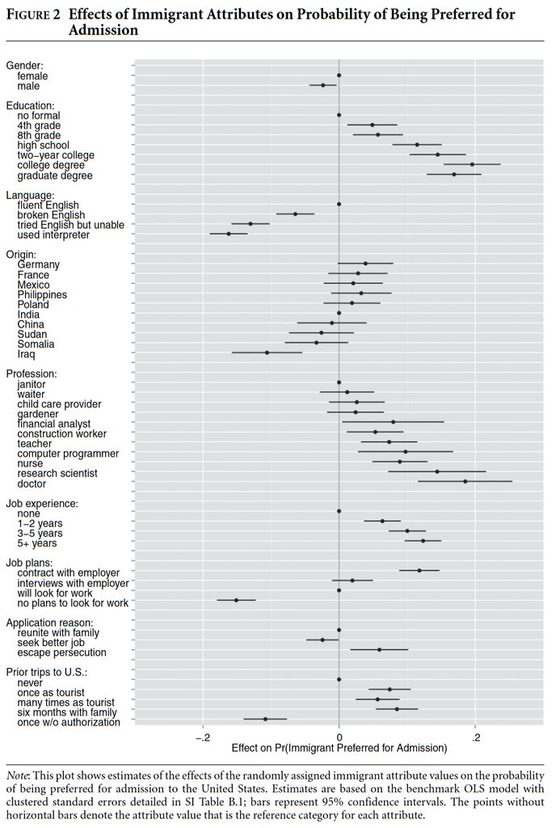

## More results…

- By self-interest
- By ethnocentrism
- By partisanship

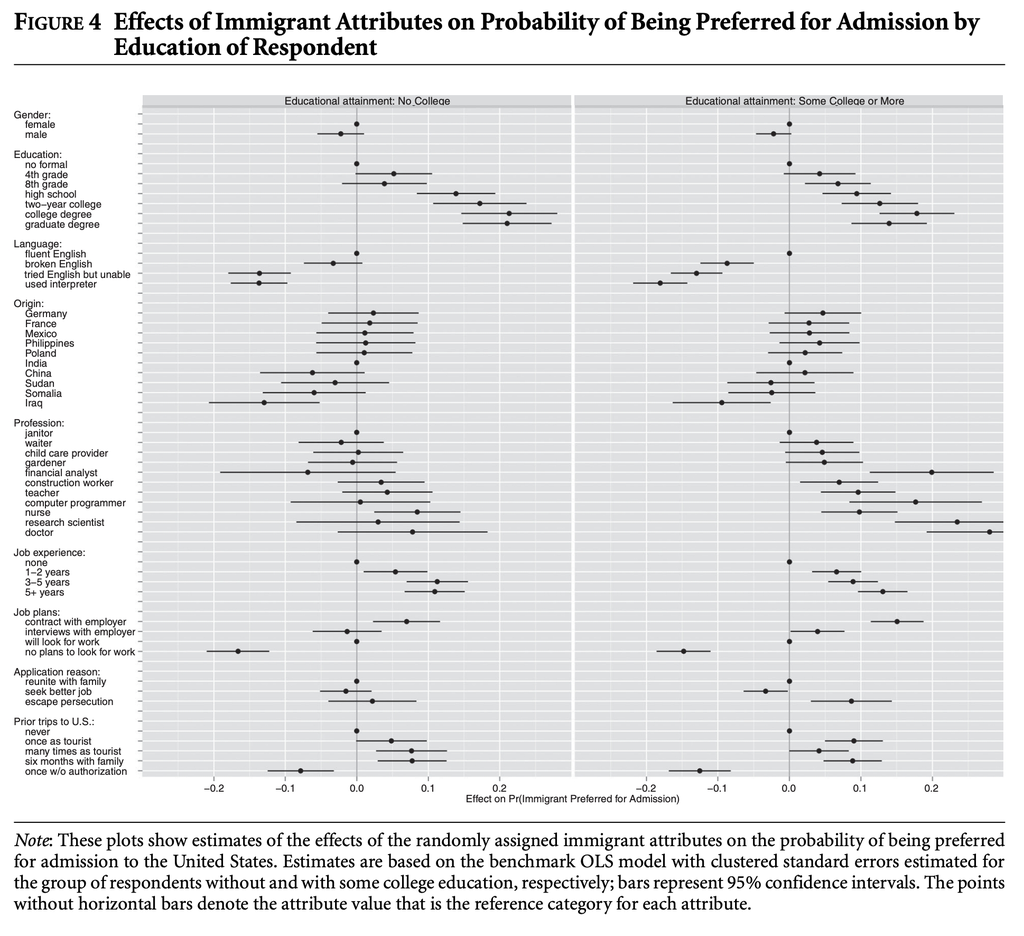

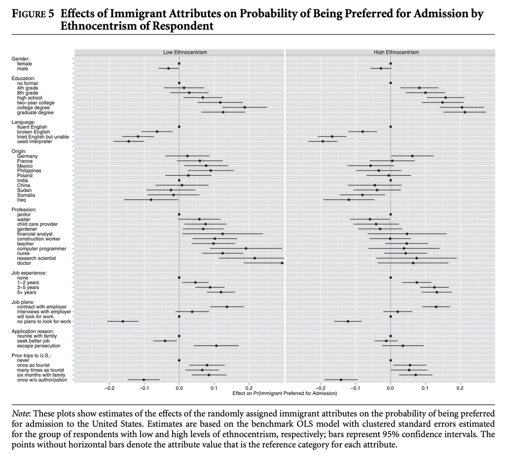

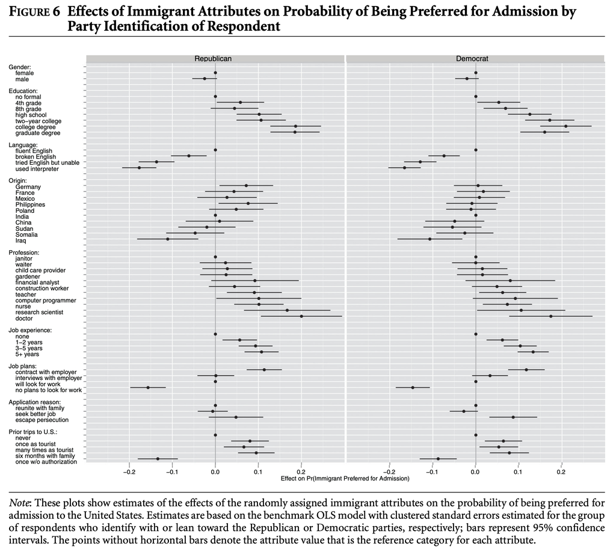

## Let’s discuss concerns

- Should we be concerned about excludability? Likely No!
- Should we be concerned about experimenter effects? Yes!
- Should we be concerned about non-interference? Yes!
- Should we be concerned about many tests that they run? Yes!
- Any other concerns?
  - Too many profiles actually could be a problem if the other features are too sparce $\Rightarrow$ ask each person to rate more than one pair of profiles
- Do you think conjoint experiments are useful? Where else can we use them?

# Campaign contributions and access

## Campaign contributions and access

- *“Campaign Contributions Facilitate Access to Congressional Officials: A Randomized Field Experiment.”* by Kalla and Broockman (2016)
- Summary:
  - Investigates whether campaign contributions increase access to congressional officials
  - Conducted a field experiment with real political donors and congressional offices
  - Found that donors are more likely to receive meetings with senior policymakers

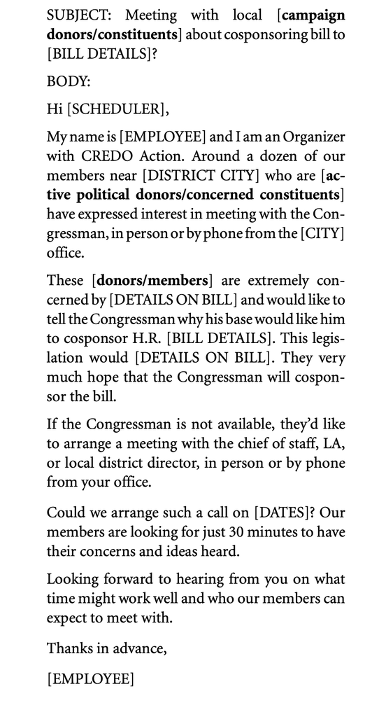

## What is the research hypothesis?

- Hypothesis: Campaign contributions increase the likelihood of gaining access to congressional officials.
- Why is this important?
  - Understanding the influence of money in politics
  - Implications for democratic representation and policy-making

## Experimental conditions? Subjects?

- What is the treatment in the study? **Disclosure of donor status**
  - Disclosure of donor status in meeting request over email
- Who (or what) are the subjects?
  - U.S. Representatives (or their office members)
- **Design:** Randomized field experiment
  - Randomly assigned meeting requests to either donor or non-donor status
  - Measured the response rate and level of access granted

## Treatment assignment and context

- How did they assign the treatment?
  - Block random assignment to one of two conditions
  - Split the sample into blocks similar units and then assign within blocks
- What is the context of the study?
  - CREDO Action initiative to build support for ban on a chemical
  - 191 U.S. Representative offices that did not cosponsor the bill

## Outcomes? Analysis?

- What are the outcomes they measure?
  1. Likelihood of receiving a meeting
  2. Level of access (e.g., meeting with senior staff or the official)
- How do they analyze the data?
  - Compare the access rates between donor and non-donor conditions
  - Look at outcomes by type of member of the office and cumulative results

## Main results

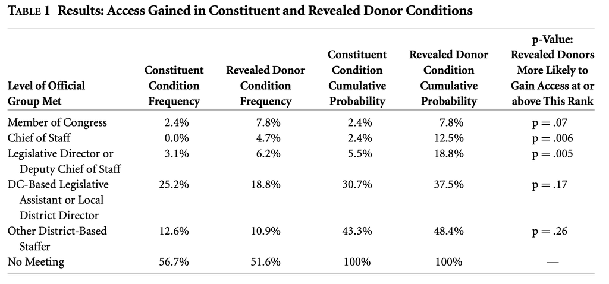

## Let’s discuss concerns

- Should we be concerned about excludability? Likely No!
- Should we be concerned about external validity? Yes!
- Should we be concerned about non-interference? Yes!
- Any other concerns?
- How might these concerns affect the interpretation of the study’s results?

## References

Hainmueller, Jens, and Daniel J. Hopkins. 2015. “The Hidden American Immigration Consensus: A Conjoint Analysis of Attitudes Toward Immigrants.” *American Journal of Political Science* 59 (3): 529–48. https://doi.org/10.1111/ajps.12138.

Kalla, Joshua L, and David E Broockman. 2016. “Campaign Contributions Facilitate Access to Congressional Officials: A Randomized Field Experiment.” *American Journal of Political Science* 60 (3): 545–58.

King, Gary, Jennifer Pan, and Margaret E. Roberts. 2014. “Reverse-Engineering Censorship in China: Randomized Experimentation and Participant Observation.” *Science* 345 (6199): 1251722. https://doi.org/10.1126/science.1251722.